# a Priori Gene Analysis - Categorical

Jared J. Homola

6/29/2020

These analyses examine the relationship between expression levels and viral titer for a set of genes that we hypothesize have a relationship with viral infection. The overall strategy is to:

1. Identify a list of candidate genes based on the literature and previous analyses.
2. Subset our overall set of transcripts to include only those with an annotation containing the name of the candidate gene in the SwissProt gene name, SwissProt gene function, KEGG pathway, or EggNOG gene orthology annotations.
3. Manually filter search results to remove non-target inclusions
4. Remove transcripts with no variation in expression for each comparison (e.g., bursa at transcript-level)
5. Perform ANOVAs for each candidate gene/transcript separate using a model of expression ~ virus shedding group + sex + weight on day 55 + age with the sequencing pool as a random effect.
6. Correct the p-values for multiple testing using a false discovery rate approach with an adjusted p-values (i.e., q-value) cutoff of 0.05.
7. Plot the results

Note: These analyses include only control and infected birds sacrificed at 1 day post-infection

## Functions for analyzing and plotting data

```r
aprioriAnalysis <- function(target, targetTissue, targetLevel, ...) {
  result1 <- lcpm.all %>%
    filter(group != "C1",
      levelGT == targetLevel,
      identifier == target,
      tissue == targetTissue) %>%
    mutate(pool = factor(pool)) %>%
    lme(lcpm ~ factor(SSgroup.virus.sac) + age + factor(sex) + wt_55, random = ~1|pool, data = .) %>%
    anova(.)

  all.result <- as_tibble(result1$`p-value`[2]) %>%
    mutate(comparison = target)

  all.result
}

aprioriPlotting <- function(target, targetTissue, targetLevel, ...) {
  lcpm.all$tmpID <- ifelse(lcpm.all$group == "C1", c('Control'), c('Infected'))

  annotation <- annot.all %>%
    filter(transcript_id == target | gene_id == target) %>%
    filter(sprot_geneName_BlastX != ".") %>%
    select(sprot_geneName_BlastX) %>%
    slice(1)

  plot <- lcpm.all %>%
    filter(levelGT == targetLevel,
           identifier == target,
           tissue == targetTissue) %>%
    mutate(SSgroup.virus.sac = fct_relevel(SSgroup.virus.sac, "CONTROL", "LOW", "MODERATE", "HIGH")) %>%
    ggplot(aes(x = SSgroup.virus.sac, y = lcpm)) +
    geom_boxplot() +
    facet_grid(. ~ tmpID, scales = "free", space = "free") +
    ylab("Log2(Counts per million)") +
    xlab("SSgroup.virus.sac") +
    theme_classic() +
    labs(title=paste0(annotation[1], " - ", target),
         subtitle=paste0(targetTissue, " - ", targetLevel))


  print(plot)
}
```

## Run analysis loop

#### Script example - others hidden

```r
#### Run analysis loop ####
targetTissue <- "Ileum" ## Bursa or Ileum
targetLevel <- "gene" ## gene or transcript
set <- lcpm.all %>%
  filter(levelGT == targetLevel, tissue == targetTissue) %>%
  group_by(identifier) %>%
  summarize(varLCPM = round(var(lcpm), 5)) %>%
  filter(varLCPM > 0)

results <- list()

for(z in unique(set$identifier)) {
  try({results[[length(results)+1]] <- aprioriAnalysis(z, targetTissue, targetLevel)}, silent = TRUE)
}

results.IG.tib <- bind_rows(results, .id = "column_label") %>%
  select(-column_label)

results.IG.tmp <- results.IG.tib %>%
  mutate(adj.p.value = p.adjust(value, method='fdr', n = nrow(.))) %>%
  filter(adj.p.value < 0.05)

results.IG.sig <- results.IG.tib %>% filter(comparison %in% results.IG.tmp$comparison)
```

## Table of results

| Tissue | Level | Analyzed | Significant |
| --- | --- | --- | --- |
| Bursa | Transcript | 1795 | 0 |
| Bursa | Gene | 747 | 1 |
| Ileum | Transcript | 1954 | 2 |
| Ileum | Gene | 812 | 0 |

## Distribution of p-values

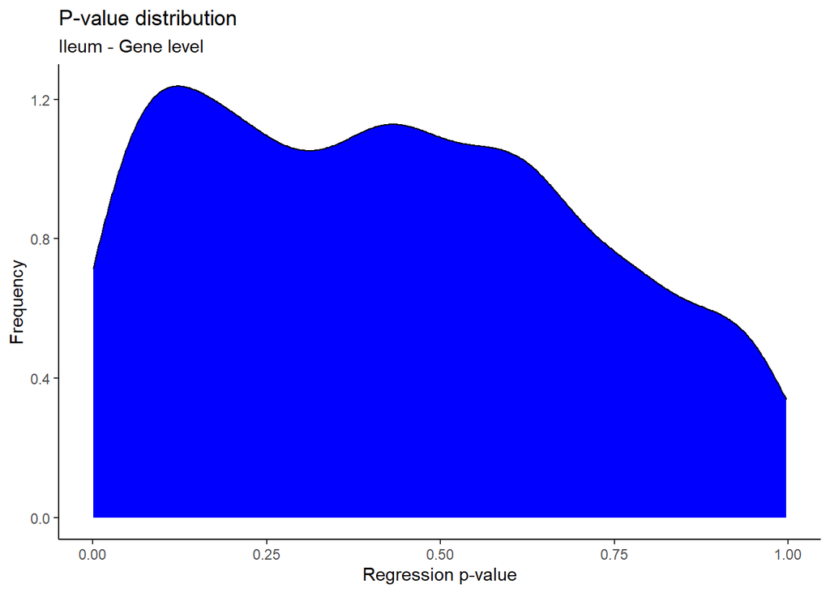

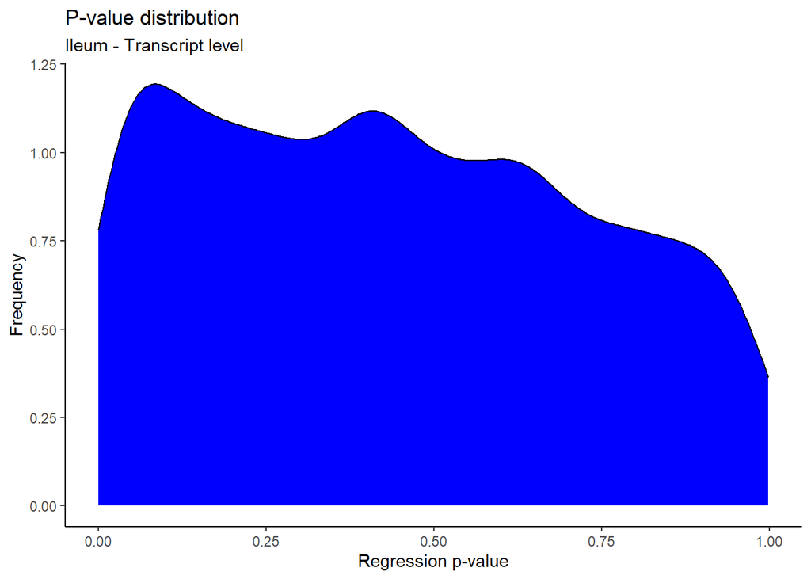

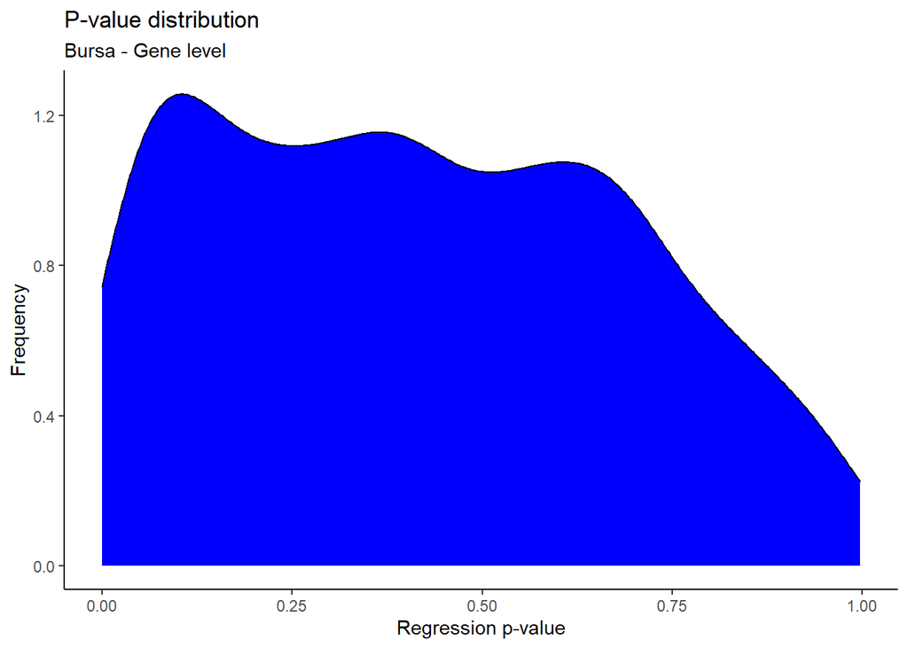

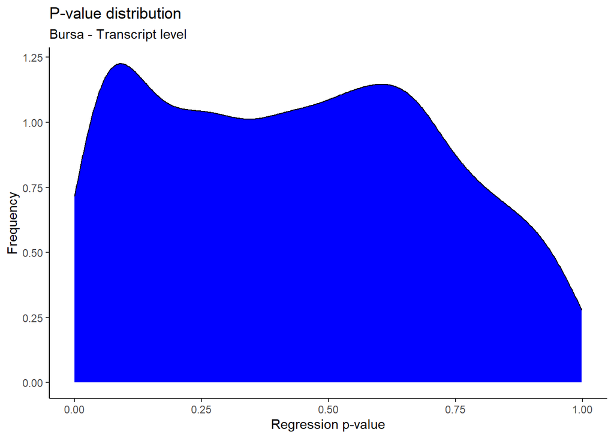

## Plotting significant results for ileum at gene level

## Plotting significant results for bursa at gene level

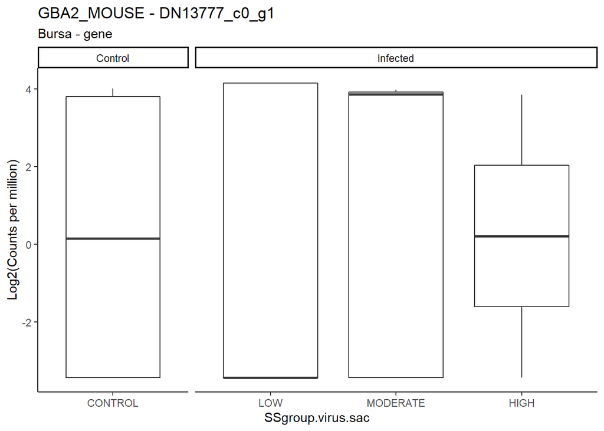

## Plotting significant results for ileum at transcript level

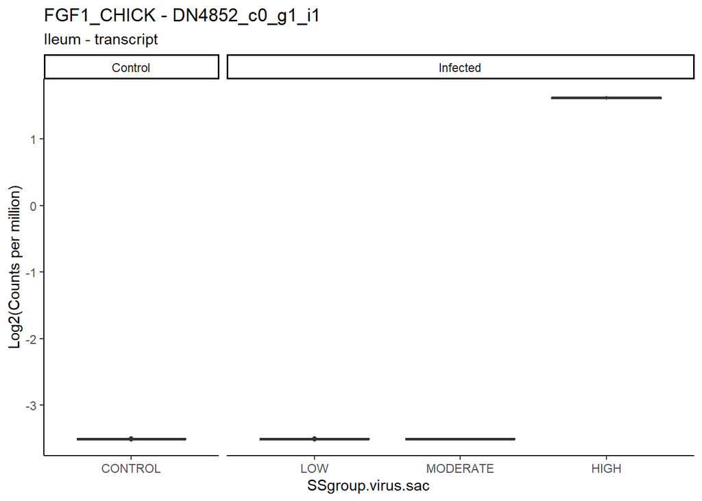

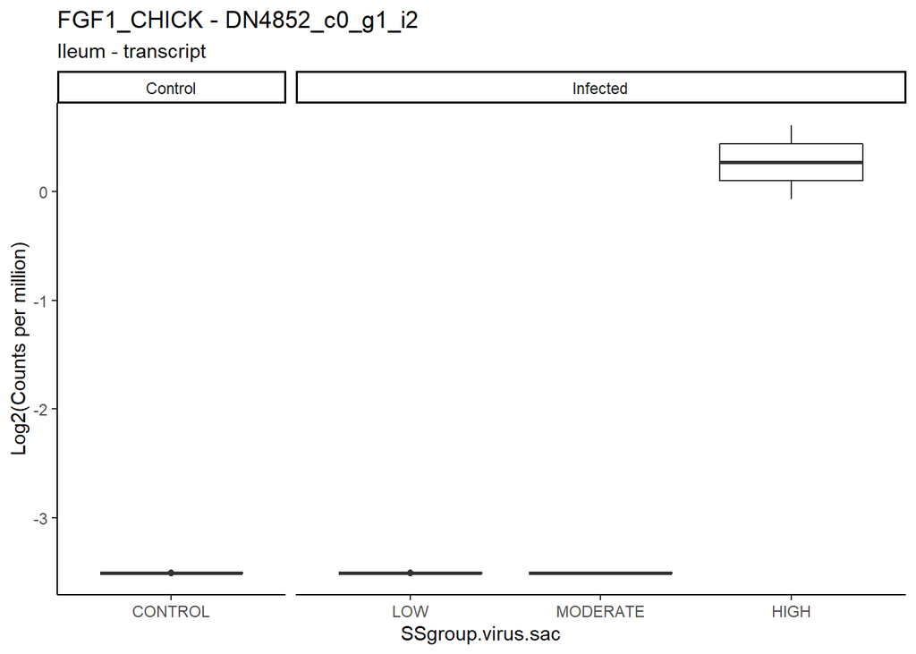

## Plotting significant results for bursa at transcript level